# Ayudantía 2

Vásquez Guerra Carlos Fernando

2023-09-01

### Correlogramas

¿Cómo será la serie de tiempo si tiene el siguiente correlograma? ¿Tenemos tendencia? ¿Estacionariedad?

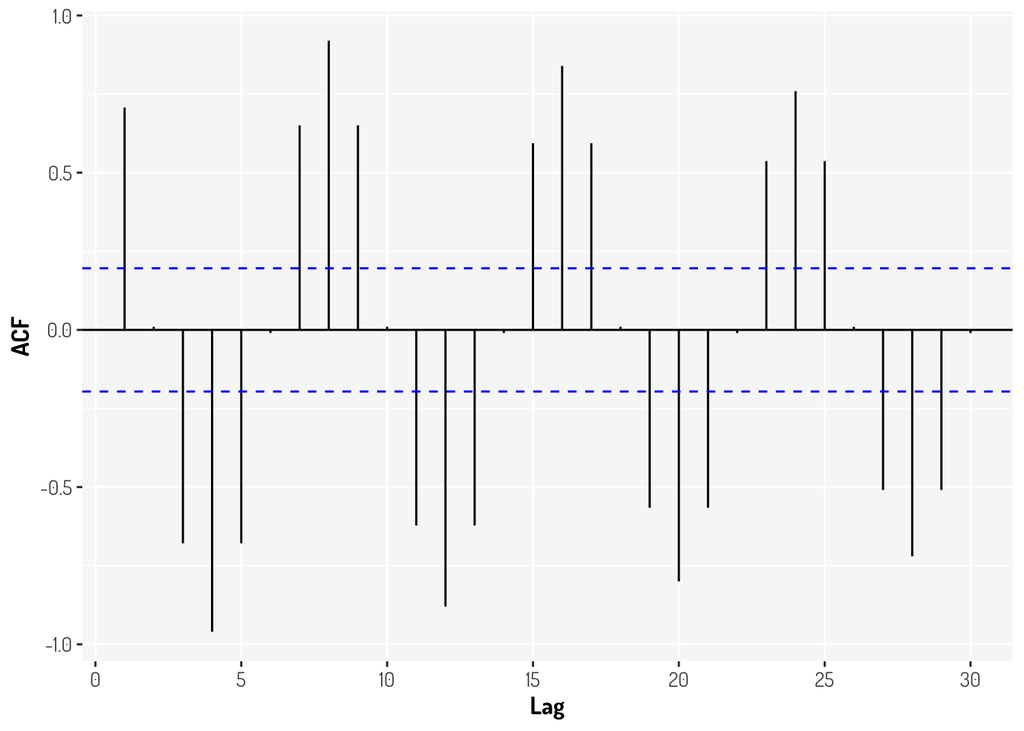

```r
tibble_sen <- tibble(x = 1:100, y = sin(x * pi/4))
sin_plot1 <- tibble_sen %>% ggplot(aes(x = x, y = y)) + geom_line() + general_theme
sin_plot2 <- ggAcf(tibble_sen$y, lag.max = 30) + ggtitle(NULL)+ general_theme
sin_plot2
```

Veamos la gráfica original.

```r
sin_plot1 / sin_plot2
```

**plot**

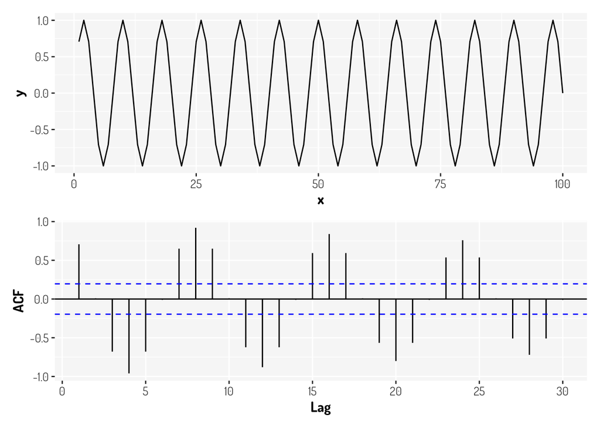

El correlograma nos ayuda a ver efectos sobre la estacionariedad y la tendencia (como su ausencia).

¿Que podemos decir de la serie fuente en este caso?

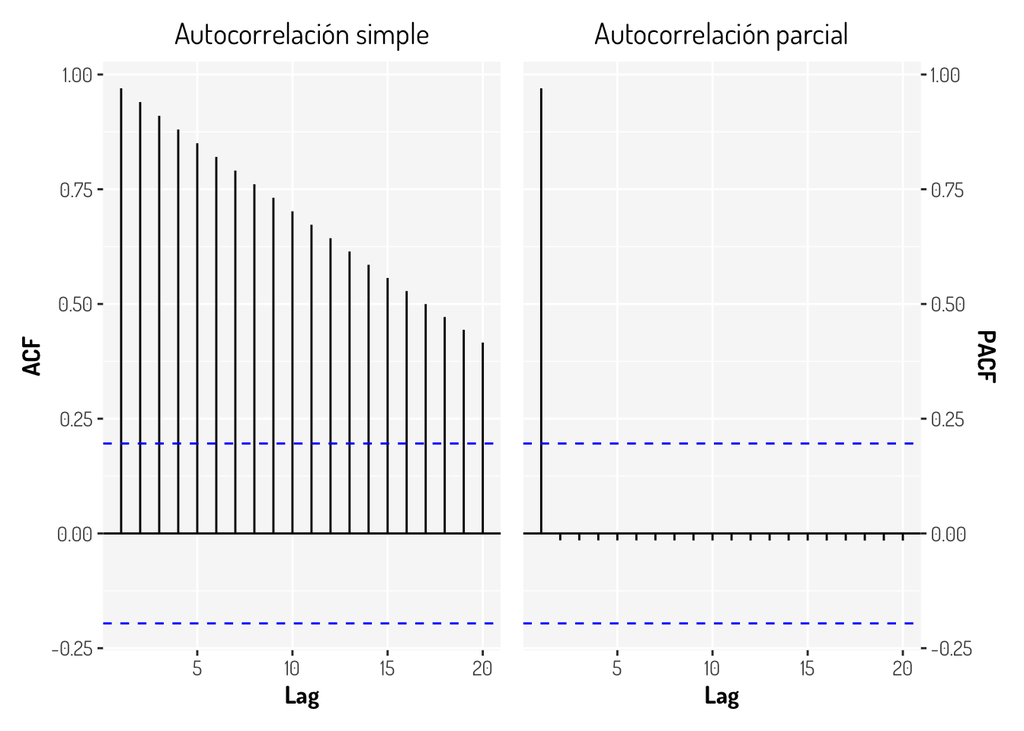

```r
((tibble(x = 1:100) %>% ggAcf()+
  ggtitle("Autocorrelación simple") +
  labs(x = "Lag", y = "ACF") +
  general_theme) +

(tibble(x = 1:100) %>% ggPacf()+
  ggtitle("Autocorrelación parcial") +
  scale_y_continuous(name = "PACF", position = 'right') +
  labs(x = "Lag") +
  general_theme))
```

Cuando tenemos problemas de estacionariedad, la autocorrelación parcial da más información sobre este componente

```r
(tibble(x = 1:100) %>% ggplot(aes(x = x, y = x)) +
  geom_point() +
  labs(x = "Tiempo", y = "f(x)") +
  general_theme) /

((tibble(x = 1:100) %>% ggAcf()+
  ggtitle("Autocorrelación simple") +
  labs(x = "Lag", y = "ACF") +
  general_theme) +

(tibble(x = 1:100) %>% ggPacf()+
  ggtitle("Autocorrelación parcial") +
  scale_y_continuous(name = "PACF", position = 'right') +
  labs(x = "Lag") +
  general_theme))
```

**plot**

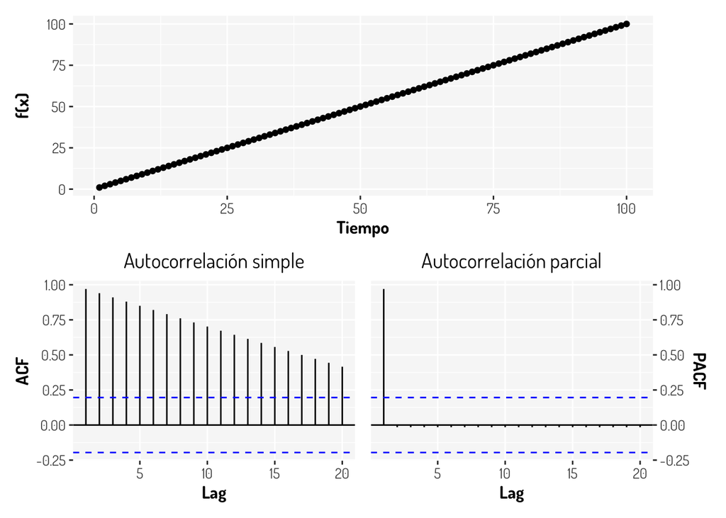

- Cuando existe una tendencia, las autocorrelaciones tenderán a ser grandes al inicio e irán decayendo a medida que aumentan los rezagos.
- Cuando existe estacionalidad, las autocorrelaciones serán más grandes para valores estacionarios (múltiplos) que en otros rezagos.
- Cuando no existe estacionalidad, la autocorrelación parcial nos aporta información relevante.

| Proceso | $ACF$ | $PACF$ |
| --- | --- | --- |
| $AR(p)$ | Decaimiento exponencial o amortiguamiento sinusoidal | Corte después del retraso $p$ |
| $MA(q)$ | Corte después del retraso $q$ | Decaimiento exponencial o amortiguamiento sinusoidal |
| ARMA(p,q) | Sin cortes bruscos | Sin cortes bruscos |

### Modelos lineales

¿Qué son los modelos AR y MA?

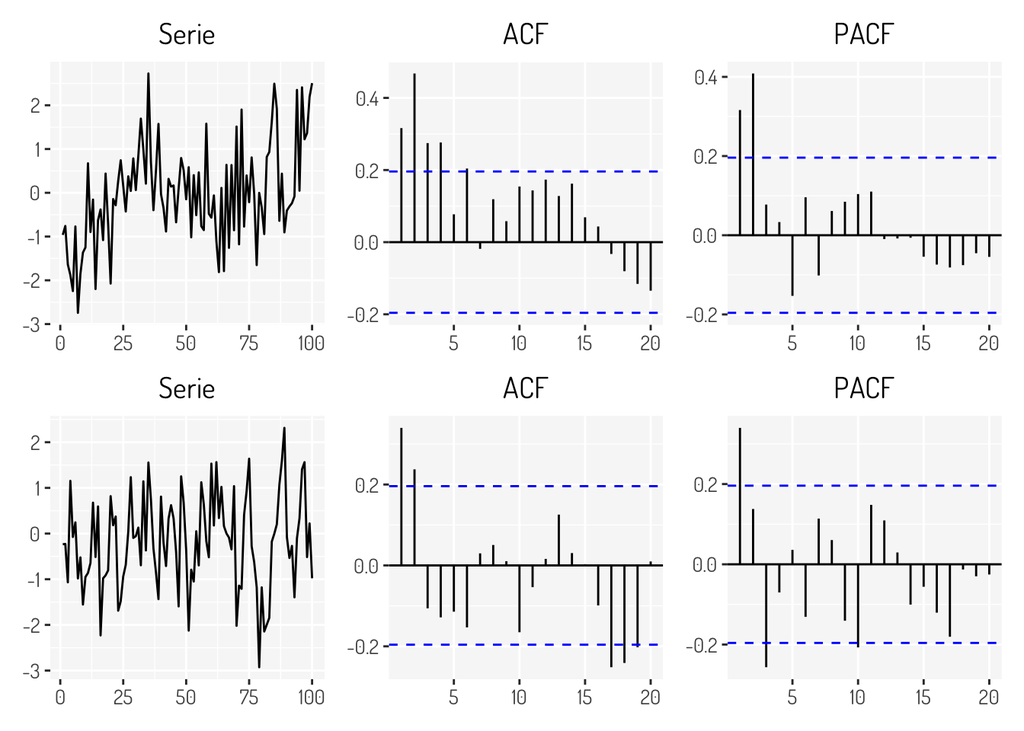

```r
set.seed(11)
#Diferentes coeficientes para los modelos AR
ARcoefficients <- c(0.3, 0.5, -0.1)
#Vamos a simular y guardar todo en una lista
AR_model <- stats::arima.sim(n = 10000, list(ar = ARcoefficients))

AM_model <- stats::arima.sim(n = 10000, list(ma = ARcoefficients))

series_plot(AR_model, 100, TRUE) /
series_plot(AM_model, 100, TRUE)
```

¿Cuándo aplicamos un ARIMA?

```r
walmart <- read_csv("walmart.csv")
walmart <- walmart %>% mutate(Date = as.Date(Date, format = '%d-%m-%Y'))
first_store <- walmart %>% filter(Store == 1)
first_week_Store_1 <- first_store$Date %>% min() %>% week()
last_week_Store_1 <- first_store$Date %>% max() %>% week()

(serie_first_store <- ts(first_store$Weekly_Sales, start = c(2010, first_week_Store_1), frequency = 52))
```

**output**

```
## Time Series:
## Start = c(2010, 6)
## End = c(2012, 44)
## Frequency = 52
##   [1] 1643691 1641957 1611968 1409728 1554807 1439542 1472516 1404430 1594968
##  [10] 1545419 1466058 1391256 1425101 1603955 1494252 1399662 1432070 1615525
##  [19] 1542561 1503284 1422712 1492418 1546074 1448939 1385065 1371987 1605492
##  [28] 1508238 1513080 1449143 1540164 1507461 1430379 1351791 1453330 1508240
##  [37] 1459409 1345454 1384209 1551659 1494479 1483784 1955624 1548034 1682614
##  [46] 1891035 2387950 1367320 1444732 1391014 1327405 1316899 1606630 1649615
##  [55] 1686843 1456800 1636263 1553192 1576818 1541102 1495065 1614259 1559889
##  [64] 1564820 1455091 1629391 1604776 1428218 1466047 1635078 1588948 1532115
##  [73] 1438830 1488538 1534850 1455120 1396927 1352220 1624384 1525147 1530761
##  [82] 1464693 1550229 1540471 1514260 1380020 1394562 1630990 1493526 1502563
##  [91] 1445249 1697230 1594939 1539484 2033321 1584084 1799682 1881177 2270189
## [100] 1497463 1550370 1459601 1394394 1319326 1636340 1802477 1819870 1539388
## [109] 1688421 1675431 1677473 1511068 1649605 1899677 1621032 1521578 1468928
## [118] 1684520 1611096 1595902 1555445 1624478 1697231 1630607 1527846 1540421
## [127] 1769854 1527014 1497955 1439124 1631136 1592410 1597868 1494122 1582083
## [136] 1661767 1517429 1506126 1437059 1670786 1573073 1508069 1493660
```

```r
(serie_first_store %>% forecast::autoplot() + general_theme) /
((serie_first_store %>% ggAcf() + general_theme + ggtitle("ACF")) +
   (serie_first_store %>% ggPacf() + ggtitle("PACF") + general_theme))
```

**plot**

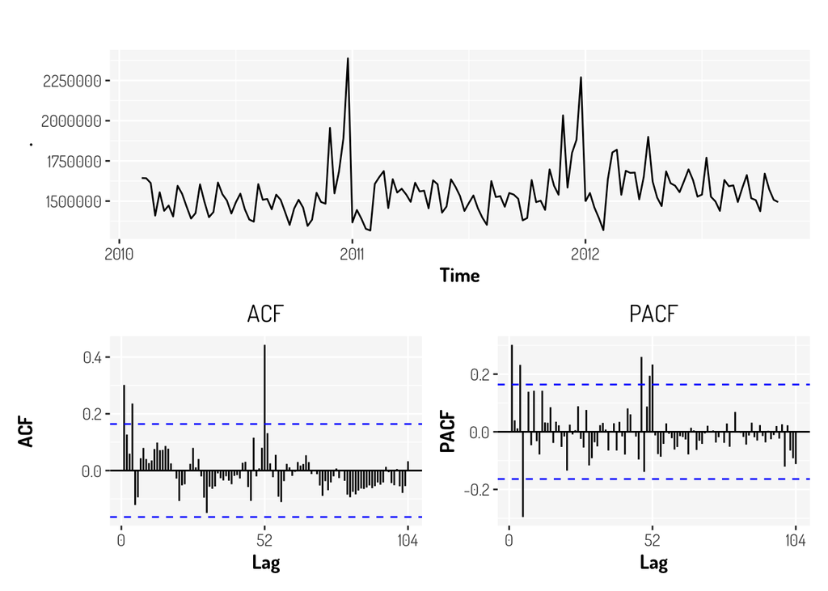

Para determinar diferencias: forecast::nsdiffs() Para ajustar modelo: forecast::Arima(diff(AirPassengers, differences = 1, lag = 12), order = c(1,0,0)) auto.arima Ljung-Box test: forecast::checkresiduals(good_model_AP) Box.test() Prediccón: good_model_AP %>% forecast(h = 30)

https://www.kaggle.com/datasets/aishu200023/stackindex

```r
stack <- read_csv("MLTollsStackOverflow.csv")
```

- Utilizamos diferencias para eliminar tendencia
- Utilizamos trasnformaciones para reducir varianza